# Discussion 7

Christine Cai

February 16, 2016

```r
dat = read.table('CH06PR09.txt')
# dat = read.table('CH06PR15.txt')
names(dat) = c('y', 'x1', 'x2', 'x3')
head(dat)
```

```
##      y     x1   x2 x3
## 1 4264 305657 7.17  0
## 2 4496 328476 6.20  0
## 3 4317 317164 4.61  0
## 4 4292 366745 7.02  0
## 5 4945 265518 8.61  1
## 6 4325 301995 6.88  0
```

Prepare a stem-and-leaf plot for $X_1$,

```r
stem(dat$x1)
```

```
##
##   The decimal point is 5 digit(s) to the right of the |
##
##   2 | 13
##   2 | 555556677777777777888999999
##   3 | 00000011222233
##   3 | 5778
##   4 | 1134
##   4 | 7
```

Obtain the scatter plot matrix,

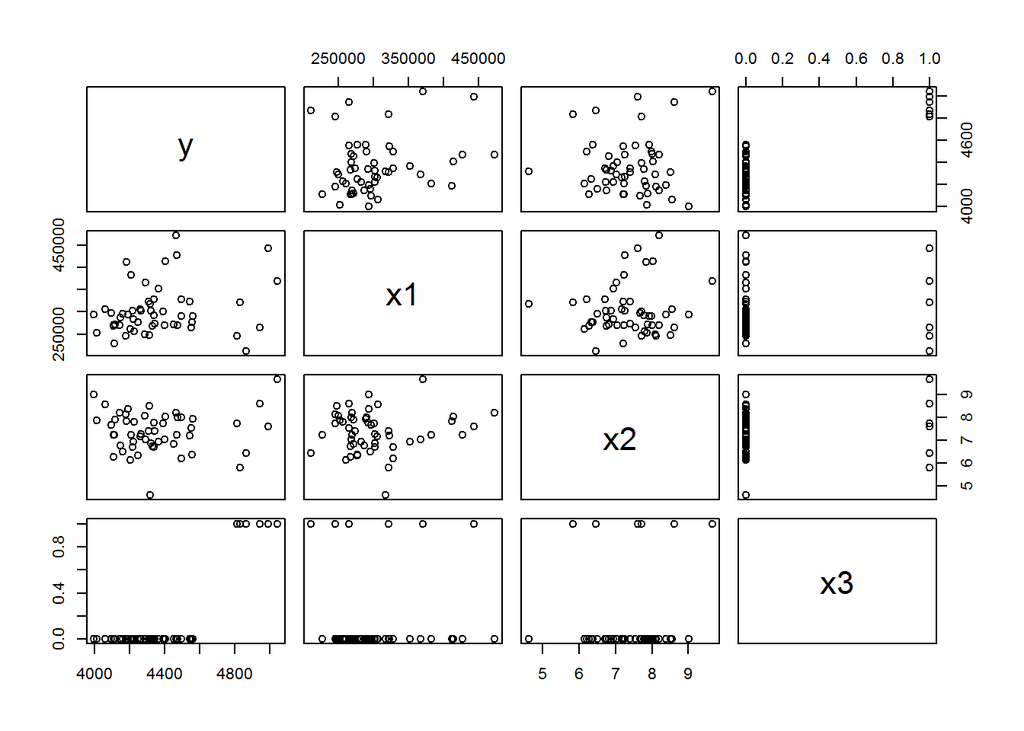

```r
plot(dat)
```

Obtain the correlation matrix,

```r
cor(dat)
```

```
##            y         x1         x2         x3
## y  1.0000000 0.20766494 0.06002960 0.81057940
## x1 0.2076649 1.00000000 0.08489639 0.04565698
## x2 0.0600296 0.08489639 1.00000000 0.11337076
## x3 0.8105794 0.04565698 0.11337076 1.00000000
```

Fit a multiple regression model,

```r
fit = lm(y ~ x1 + x2 + x3, data = dat); fit
```

```
##
## Call:
## lm(formula = y ~ x1 + x2 + x3, data = dat)
##
## Coefficients:
## (Intercept)           x1           x2           x3
##   4.150e+03    7.871e-04   -1.317e+01    6.236e+02
```

Or equivalently,

```r
fit = lm(y ~ ., data = dat); fit
```

```
##
## Call:
## lm(formula = y ~ ., data = dat)
##
## Coefficients:
## (Intercept)           x1           x2           x3
##   4.150e+03    7.871e-04   -1.317e+01    6.236e+02
```

Most of what we’ve learned for simple regression carries over for multiple regression. For example, to extract the residuals from the lm object ‘fit’, we would use the familiar `fit$res`.

Plot the residuals against the two-factor interaction term $X_1X_2$,

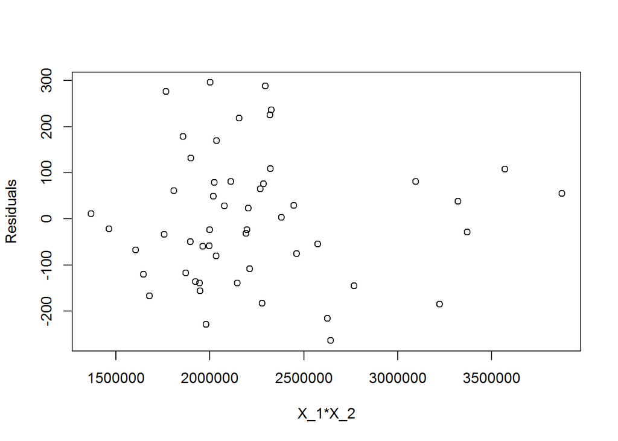

```r
plot(dat$x1*dat$x2, fit$res, xlab = 'X_1*X_2', ylab = 'Residuals')
```

For multiple regression, the default ANOVA table in R gives extra sums of squares. Please read chapter 7 carefully and write down the extra sums of squares definitions on your cheat sheet.

```r
anova(fit)
```

```
## Analysis of Variance Table
##
## Response: y
##           Df  Sum Sq Mean Sq F value    Pr(>F)
## x1         1  136366  136366  6.6417   0.01309 *
## x2         1    5726    5726  0.2789   0.59987
## x3         1 2034514 2034514 99.0905 2.941e-13 ***
## Residuals 48  985530   20532
## ---
## Signif. codes:  0 '***' 0.001 '**' 0.01 '*' 0.05 '.' 0.1 ' ' 1
```

Going from top to bottom in the ‘Sum Sq’ column, the entries are $SSR(X_1),\ SSR(X_2|X_1),\ SSR(X_3|X_1, X_2), \text{ and } SSE(X_1, X_2, X_3).$

In testing whether there is a regression relation, the F-statistic is

```r
f.star = (136366+5726+2034514)/3/20532; f.star
```

```
## [1] 35.33681
```

Calculate the coefficient of multiple determination,

```r
r.sq = (136366+5726+2034514)/(136366+5726+2034514+985530); r.sq
```

```
## [1] 0.6883341
```

Or

```r
r.sq = 1 - 985530/(136366+5726+2034514+985530); r.sq
```

```
## [1] 0.6883341
```

Obtain $\hat{Y}_h$ with $X_{h1} = 282,000$, $X_{h2} = 7.10$, and $X_{h3} = 0$,

```r
x.h = c(1, 282000, 7.1, 0)
y.h = t(x.h)%*%fit$coef; y.h
```

```
##          [,1]
## [1,] 4278.365
```

Obtain $s\{\hat{Y}_h\}$,

```r
mse = summary(fit)$sigma^2; mse
```

```
## [1] 20531.87
```

```r
X = model.matrix(fit); head(X)
```

```
##   (Intercept)     x1   x2 x3
## 1           1 305657 7.17  0
## 2           1 328476 6.20  0
## 3           1 317164 4.61  0
## 4           1 366745 7.02  0
## 5           1 265518 8.61  1
## 6           1 301995 6.88  0
```

```r
s.yh = sqrt(mse*(t(x.h)%*%solve(t(X)%*%X)%*%x.h)); s.yh
```

```
##          [,1]
## [1,] 22.83758
```

The hw problems in chapter 7 mostly just involve the fitting and refitting of many different models.

Suppose instead of $SSR(X_1),\ SSR(X_2|X_1),\ SSR(X_3|X_1, X_2), \text{ and } SSE(X_1, X_2, X_3),$ we want $SSR(X_2),\ SSR(X_1|X_2),\ SSR(X_3|X_1, X_2), \text{ and } SSE(X_1, X_2, X_3),$ we just have to change the order of the predictors when we fit our model.

```r
fit = lm(y ~ x2 + x1 + x3, data = dat); fit
```

```
##
## Call:
## lm(formula = y ~ x2 + x1 + x3, data = dat)
##
## Coefficients:
## (Intercept)           x2           x1           x3
##   4.150e+03   -1.317e+01    7.871e-04    6.236e+02
```

```r
anova(fit)
```

```
## Analysis of Variance Table
##
## Response: y
##           Df  Sum Sq Mean Sq F value    Pr(>F)
## x2         1   11395   11395  0.5550    0.4599
## x1         1  130697  130697  6.3656    0.0150 *
## x3         1 2034514 2034514 99.0905 2.941e-13 ***
## Residuals 48  985530   20532
## ---
## Signif. codes:  0 '***' 0.001 '**' 0.01 '*' 0.05 '.' 0.1 ' ' 1
```

In testing whether $X_3$ can be dropped given that $X_1$ and $X_2$ are retained, the F-statistic is

```r
f.star = 2034514/20532; f.star
```

```
## [1] 99.08991
```